# Exploring the BRFSS data

## Setup

### Load packages

```r
library(ggplot2)
library(dplyr)
```

### Load data

```r
load("brfss2013.RData")
```

## Part 1: Data

The purpose of the Behavioral Risk Factor Surveillance System (BRFSS) study is to measure behavioral risk factors for the non-institutionalized adult population (18 years of age and older) residing in the US. The BRFSS collects data annually from 50 states and other participating U.S. territories (D.C, Guam, Puerto Rico) through landline telephone and cellular telephone surveys. In the BRFSS telephone surveys (both landline and cellular), a sample record (or observation) is one telephone number in the list of all telephone numbers the system randomly selects for dialing. The target population for the landline samples are non-institutionalized adults (18 or older) in a household who reside in the US. Target population for cellular telephone samples consists of non-institutionalized persons residing in a private residence or college housing, who have a working cellular telephone, are aged 18 and older, and received 90 percent or more of their calls on cellular telephones. This is an observational study because the study did not assign any treatments to the study’s population. It instead conducted surveys. Thus, the 3 research questions I chosen are non-causal.

## Part 2: Research questions

**Research quesion 1:** Is there a relationship or association between smoking (x variable) and quality of sleep (y variable)?

**Research quesion 2:** Is there a relationship or association between one’s own opinion of their general health and amount of exercise per week (walking, running, jogging, or swimming) the person gets?

**Research quesion 3:** Is there a relationship or association between education level and owning a home?

## Part 3: Exploratory data analysis

**Research quesion 1:** Is there a relationship or association between smoking (x variable) and quality of sleep (y variable)?

Starting off, I created a new data set with two variables from the brfss2013 data set- smokday2 (categorical variable) and sleptim1 (numerical variable). I then filtered out the variables that contain NAs. NOTE: The head command is used to provide a quick view of the data set without having to ouput all 211,584 rows of data.

```r
Smoking_Sleep <- select(brfss2013, smokday2, sleptim1)
Smoking_Sleep <- Smoking_Sleep %>% filter(!is.na(smokday2), !is.na(sleptim1))
head(Smoking_Sleep, n = 20)
```

```
##      smokday2 sleptim1
## 1   Some days        9
## 2  Not at all        6
## 3  Not at all        7
## 4   Every day        6
## 5   Every day        3
## 6   Some days        8
## 7   Every day        5
## 8  Not at all        8
## 9  Not at all        7
## 10  Every day        8
## 11 Not at all        6
## 12 Not at all        7
## 13 Not at all        8
## 14  Every day        7
## 15 Not at all        5
## 16  Every day        7
## 17 Not at all        6
## 18  Every day        7
## 19 Not at all        5
## 20 Not at all        8
```

The new data set trimmed down the number of observations in the brfss2013 table from 491,775 to 211,584 observations.

In my next set of code, I mutated the Smoking_Sleep data to create a new variable called Sleep_Quality. This variable categorizes the observations (or respondents in the survey) into two groups based on their average amount of sleep they get per night - quality sleep, not quality sleep

```r
Smoking_Sleep <- Smoking_Sleep %>% mutate(Sleep_Quality = ifelse(sleptim1 == 7| sleptim1 == 8 | sleptim1 == 9, "quality sleep", "not quality sleep"))
head(Smoking_Sleep, n = 20)
```

```
##      smokday2 sleptim1     Sleep_Quality
## 1   Some days        9     quality sleep
## 2  Not at all        6 not quality sleep
## 3  Not at all        7     quality sleep
## 4   Every day        6 not quality sleep
## 5   Every day        3 not quality sleep
## 6   Some days        8     quality sleep
## 7   Every day        5 not quality sleep
## 8  Not at all        8     quality sleep
## 9  Not at all        7     quality sleep
## 10  Every day        8     quality sleep
## 11 Not at all        6 not quality sleep
## 12 Not at all        7     quality sleep
## 13 Not at all        8     quality sleep
## 14  Every day        7     quality sleep
## 15 Not at all        5 not quality sleep
## 16  Every day        7     quality sleep
## 17 Not at all        6 not quality sleep
## 18  Every day        7     quality sleep
## 19 Not at all        5 not quality sleep
## 20 Not at all        8     quality sleep
```

Next, I computed the proportion of individuals who do not get quality amount of sleep (less than or more than the 7 to 9 hour range) and grouped them by their frequency of days smoking- Every day, Some days, Not at all.

```r
Smoking_Sleep2 <- Smoking_Sleep %>% group_by(smokday2) %>% summarise(Sleep_Quality_Prop = sum(Sleep_Quality == "not quality sleep")/n()) %>% arrange(desc(Sleep_Quality_Prop))
Smoking_Sleep2
```

```
## # A tibble: 3 × 2
##     smokday2 Sleep_Quality_Prop
##       <fctr>              <dbl>
## 1  Every day          0.4960273
## 2  Some days          0.4593586
## 3 Not at all          0.3486259
```

As you can see in the Smoking_Sleep2 table, the subset population of Every day smokers has the highest proportion of people who not get quality sleep whereas people who do not smoke at all have the lowest proportion.

To get a better visualisation of this, I created a bar plot.

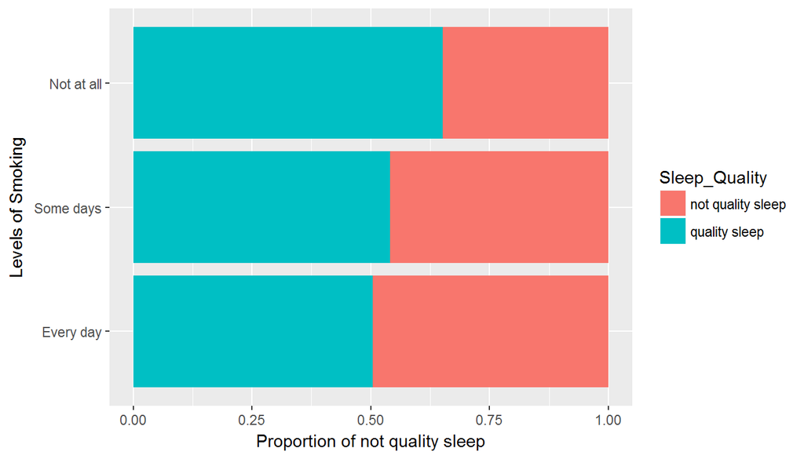

```r
Smoking_Sleep %>% group_by(smokday2) %>% ggplot() + aes(x = smokday2, fill = Sleep_Quality) + geom_bar(position = "fill") + labs(y = "Proportion of not quality sleep", x = "Levels of Smoking") + coord_flip()
```

The bar plot clearly shows that people who do not smoke at all get more quality sleep than people who smoke, whether that be some days or every day. We definitely can’t infer causation between quality of sleep and smoking since this is observational data and none of the respondents of this survey were assigned to an experiement. As for correlation between the two variables, there are a lot of other factors that can affect one’s sleep quality other than frequency of smoking. I do think it’s noteworthy, however, that the proportion of low quality sleepers amongst people who do not smoke at all is roughly 15% lower than that of people of smoke every day.

**Research quesion 2:** Is there a relationship or association between one’s own opinion of their general health and amount of exercise per week (walking, running, jogging, or swimming) the person gets?

I selected two variables from the brfss2013 dataset and created a new dataset called Health_Exercise. I then filtered out the variables that contain NAs

```r
Health_Exercise <- select(brfss2013, genhlth, exeroft1)
Health_Exercise <- Health_Exercise %>% filter(!is.na(genhlth), !is.na(exeroft1))
```

After that, I filtered the exeroft1 variable to focus on just times per week rather than times per week OR times per month. The number of observations listed is now 233,452 due to this filter.

```r
Health_Exercise <- filter(Health_Exercise, exeroft1 >100)
Health_Exercise <- filter(Health_Exercise, exeroft1 < 200) %>% arrange(desc(exeroft1))
head(Health_Exercise, n = 20)
```

```
##      genhlth exeroft1
## 1  Very good      199
## 2       Good      199
## 3  Very good      199
## 4  Very good      199
## 5  Very good      199
## 6       Poor      199
## 7       Fair      199
## 8       Good      199
## 9       Fair      199
## 10      Fair      199
## 11      Good      199
## 12      Good      199
## 13      Fair      199
## 14      Good      199
## 15      Fair      199
## 16      Poor      199
## 17 Excellent      199
## 18 Excellent      190
## 19 Very good      176
## 20 Excellent      176
```

The mutated variable- exercise_per_week- is basically exeroft1 minus 100. This simplifies the values in the exeroft1 variable so I know the exact times per week a respondent works out rather than having to decipher the code for each observation.

```r
Health_Exercise <- Health_Exercise %>% mutate(exercise_per_week = exeroft1- 100)
```

I noticed that roughly 4,250 of the 233, 452 respondents claimed they worked out more than 7 times a week with some respondents claiming they worked out 99 times a week. After this observation of mine, I concluded that I would like to trim down the data to just focus on respondents who work out no more than 7 times a week. In doing so, I filtered the exercise_per_week variable for values greater than or equal to 1 and less than or equal to 7. In other words, filtering for respondents who fall between the 1 to 7 workouts a week range.

```r
 Health_Exercise <- filter(Health_Exercise, exercise_per_week >= 1)
 Health_Exercise <- filter(Health_Exercise, exercise_per_week <= 7) %>% arrange(desc(exercise_per_week))
head(Health_Exercise, n =20)
```

```
##      genhlth exeroft1 exercise_per_week
## 1  Excellent      107                 7
## 2       Good      107                 7
## 3       Fair      107                 7
## 4  Excellent      107                 7
## 5       Good      107                 7
## 6  Very good      107                 7
## 7       Poor      107                 7
## 8       Fair      107                 7
## 9  Excellent      107                 7
## 10 Excellent      107                 7
## 11      Fair      107                 7
## 12      Fair      107                 7
## 13      Good      107                 7
## 14      Good      107                 7
## 15      Poor      107                 7
## 16 Excellent      107                 7
## 17 Excellent      107                 7
## 18      Poor      107                 7
## 19 Excellent      107                 7
## 20 Very good      107                 7
```

Next, I calculated proportions grouped by the exercise_per_week variable. As you can see in the code below, the total population for each numerical level (i.e. 1,2,3,4,5,6,7) in the exercise_per_week variable is added up, which acts as the denominator in the calculation of the proportion. The numerator, on the other hand, is the total number of people for each level (i.e poor, fair, good, etc.) in the genhlth variable within its respective exercise_per_week variable population. For example, there’s a total of 19,990(denominator) people who workout 1 time a week and of that population, 3,308 (numerator) people believe their health to be excellent. Therefore the proportion is 3,308/19,990 = .165. Using these proportion numbers will be of good use to both better visualize and analyze my graph (see below).

```r
Health_Exercise2 <- Health_Exercise %>% group_by(exercise_per_week, genhlth) %>% summarise(subtotal= n()) %>%  group_by(exercise_per_week) %>%  mutate(proportion = subtotal / sum(subtotal)) %>% arrange(desc(proportion))
 Health_Exercise2 %>% knitr::kable()
```

| exercise_per_week | genhlth | subtotal | proportion |
| --- | --- | --- | --- |
| 4 | Very good | 11625 | 0.3992924 |
| 3 | Very good | 23011 | 0.3893702 |
| 5 | Very good | 12083 | 0.3880841 |
| 2 | Very good | 14752 | 0.3812576 |
| 6 | Very good | 3928 | 0.3634009 |
| 1 | Very good | 7198 | 0.3600800 |
| 1 | Good | 6473 | 0.3238119 |
| 7 | Very good | 12619 | 0.3126378 |
| 2 | Good | 11931 | 0.3083503 |
| 7 | Good | 12117 | 0.3002007 |
| 3 | Good | 16776 | 0.2838675 |
| 6 | Excellent | 3010 | 0.2784716 |
| 5 | Good | 8017 | 0.2574916 |
| 4 | Good | 7417 | 0.2547572 |
| 5 | Excellent | 7906 | 0.2539264 |
| 4 | Excellent | 7388 | 0.2537611 |
| 6 | Good | 2705 | 0.2502544 |
| 3 | Excellent | 12649 | 0.2140343 |
| 7 | Excellent | 8052 | 0.1994896 |
| 2 | Excellent | 6978 | 0.1803427 |
| 1 | Excellent | 3308 | 0.1654827 |
| 7 | Fair | 5464 | 0.1353715 |
| 1 | Fair | 2311 | 0.1156078 |
| 2 | Fair | 3924 | 0.1014137 |
| 3 | Fair | 5315 | 0.0899354 |
| 6 | Fair | 883 | 0.0816912 |
| 5 | Fair | 2496 | 0.0801670 |
| 4 | Fair | 2126 | 0.0730233 |
| 7 | Poor | 2111 | 0.0523004 |
| 1 | Poor | 700 | 0.0350175 |
| 2 | Poor | 1108 | 0.0286357 |
| 6 | Poor | 283 | 0.0261819 |
| 3 | Poor | 1347 | 0.0227926 |
| 5 | Poor | 633 | 0.0203308 |
| 4 | Poor | 558 | 0.0191660 |

Before I entered the code for my graph, I noticed that the most common response for the genhlth variable is Very Good, for all levels in the exercise_per_week variable. To confirm this observation of mine, I ran the code below. As you can see, the code confirms my observation that Very Good has the highest proportion for each level in the exercise_per_week variable.

```r
Health_Exercise2 %>% group_by(exercise_per_week) %>% arrange(desc(proportion)) %>% slice(1) %>% ungroup()
```

```
## # A tibble: 7 × 4
##   exercise_per_week   genhlth subtotal proportion
##               <dbl>    <fctr>    <int>      <dbl>
## 1                 1 Very good     7198  0.3600800
## 2                 2 Very good    14752  0.3812576
## 3                 3 Very good    23011  0.3893702
## 4                 4 Very good    11625  0.3992924
## 5                 5 Very good    12083  0.3880841
## 6                 6 Very good     3928  0.3634009
## 7                 7 Very good    12619  0.3126378
```

This graph (along with the aid of the proportion numbers) allows you to better visualize this exploratory data analysis between how many times people work out a week and what they believe their general health to be.

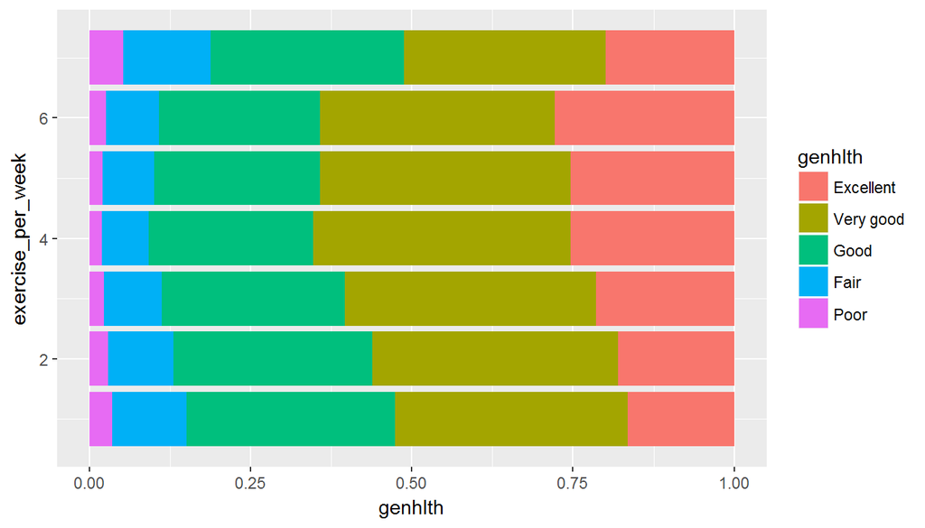

```r
Health_Exercise %>% group_by(exercise_per_week) %>% ggplot() + aes(x = exercise_per_week, fill = genhlth) + geom_bar(position = "fill") + labs(y= "genhlth", x = "exercise_per_week") + coord_flip()
```

Scope of inference- generalizability: Can these results - that majority of the sample population who workout between the 1 to 7 times a week range believes their health to be in good standing- be generalized to the rest of this population (outside of the data set)? Even though this data is randomly sampled, I don’t think a generalization can be made mainly because data from 160,000 respondents in the exeroft1 variable are missing (see exeroft1 variable in the codebook). That’s a lot of missing observations. If I had access to the missing data and used them in my analysis, my findings could be disproved or altered, depending on the respondent’s answers. Moreover, there are other factors (or variables) that can influence or, at the very least, provide insight into what criteria people use to determine their general health other than just exercising. Having health insurance is one factor that comes to mind.

Bias- Aside from the missing data, there are other potential biases I noticed in the data I used. Just because someone believes their health to be Poor, Fair, Good, Very Good, or Excellent doesn’t mean it actually is. You can have someone, for example, who, from a clinical standpoint, is healthy, but the person answers Poor because they have a negative perception of their body image. Another example, an individual who workouts 7 times a week for long hours each time and doesn’t eat the proper nutrients needed because he/she is trying to attain a certain body image. In this person’s mind, he/she may believe their health to be Excellent because they believe they’re on the track to achieving their ideal body image but in reality their body is malnourished and most likely fatigued on a constant basis.

**Research quesion 3:** Is there a relationship or association between education level and owning a home?

I selected two categorical variables from the brfss2013 data set- educa and renthom1. I then filtered these variables to weed out any NAs

```r
Income_Education <- select(brfss2013, educa, renthom1)
Income_Education <- Income_Education %>% filter(!is.na(educa), !is.na(renthom1))
```

I wanted to simplify the educa variable by focusing only on respondents who have a college degree or a highschool graduate degree. Therefore, I ran the subset command on the educa variable in my Income_Education data set to only select respondents who answered yes to either “College 4 years or more (College graduate)” or “Grade 12 or GED (High school graduate)”).

```r
Income_Education = subset(Income_Education, educa == "College 4 years or more (College graduate)" |educa == "Grade 12 or GED (High school graduate)")
head(Income_Education, n =20)
```

```
##                                         educa renthom1
## 1  College 4 years or more (College graduate)      Own
## 3  College 4 years or more (College graduate)      Own
## 4      Grade 12 or GED (High school graduate)      Own
## 5  College 4 years or more (College graduate)      Own
## 6  College 4 years or more (College graduate)      Own
## 7      Grade 12 or GED (High school graduate)      Own
## 9  College 4 years or more (College graduate)      Own
## 10     Grade 12 or GED (High school graduate)      Own
## 11 College 4 years or more (College graduate)      Own
## 12 College 4 years or more (College graduate)     Rent
## 14 College 4 years or more (College graduate)      Own
## 16 College 4 years or more (College graduate)      Own
## 17     Grade 12 or GED (High school graduate)     Rent
## 19     Grade 12 or GED (High school graduate)      Own
## 21 College 4 years or more (College graduate)      Own
## 22 College 4 years or more (College graduate)      Own
## 23 College 4 years or more (College graduate)      Own
## 24 College 4 years or more (College graduate)      Own
## 29 College 4 years or more (College graduate)      Own
## 30     Grade 12 or GED (High school graduate)      Own
```

```r
Income_Education2 <- Income_Education %>% group_by(educa, renthom1) %>% summarise(subtotal= n()) %>%  group_by(renthom1) %>%  mutate(proportion = subtotal / sum(subtotal)) %>% arrange(desc(proportion))
Income_Education2 %>% knitr::kable()
```

| educa | renthom1 | subtotal | proportion |
| --- | --- | --- | --- |
| Grade 12 or GED (High school graduate) | Other arrangement | 7200 | 0.6372245 |
| College 4 years or more (College graduate) | Own | 136256 | 0.5819822 |
| Grade 12 or GED (High school graduate) | Rent | 35573 | 0.5650634 |
| College 4 years or more (College graduate) | Rent | 27381 | 0.4349366 |
| Grade 12 or GED (High school graduate) | Own | 97868 | 0.4180178 |
| College 4 years or more (College graduate) | Other arrangement | 4099 | 0.3627755 |

This graph provides a good visualization of the disparity between home owners who are college graduates and high school graduates who are home owners.

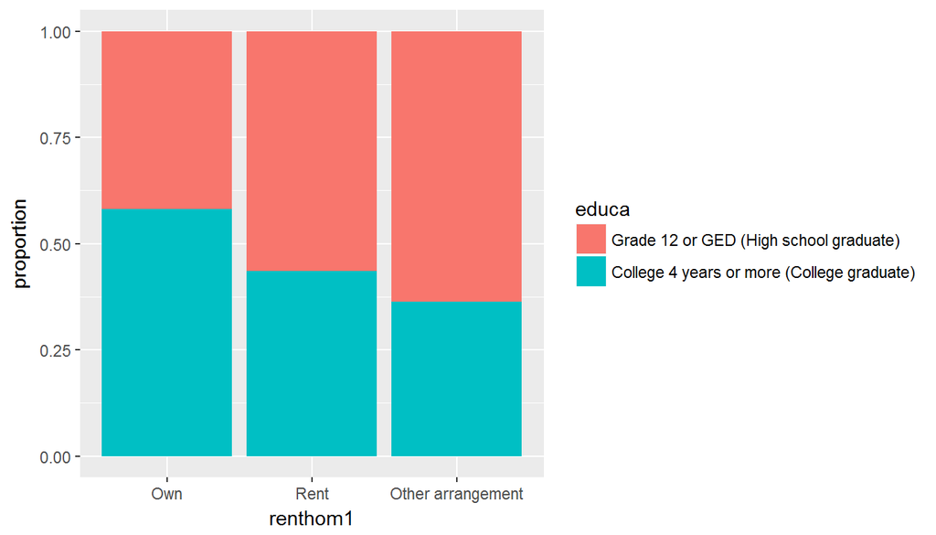

```r
ggplot(data=Income_Education2, aes(x=renthom1, y = proportion, fill=educa)) +geom_bar(stat="identity")
```

Conclusion: With strong evidence showing that a higher proportion of college graduates owning a home in comparison to high school graduates, I think this finiding can be generalized to the rest of the population outside of this data set. However, it must be noted that part of the reason why this data reveals that there’s a higher proportion of college graduates who own a home is because of their age. With age comes experience both in life and on the job. I would have liked to included age in the EDA question but the brfss2013 data set does not have that variable.